# Predicting Breast Cancer using Decision Trees

Hugo Argueta

May 9, 2017

```r
> library(rpart)
> library(rpart.plot)
```

### Load data

```r
> set.seed(135)
>
> dat = read.csv("/Users/juice/Documents/CST463/final-project/breast-cancer-prediction/data.csv")
> dat$X = NULL
```

### Split dataset into training set and testing set

```r
> num_tr = sample(1:nrow(dat), floor(nrow(dat) * .75))
> tr_dat = dat[num_tr,]
> te_dat = dat[-num_tr,]
```

### Data exploration

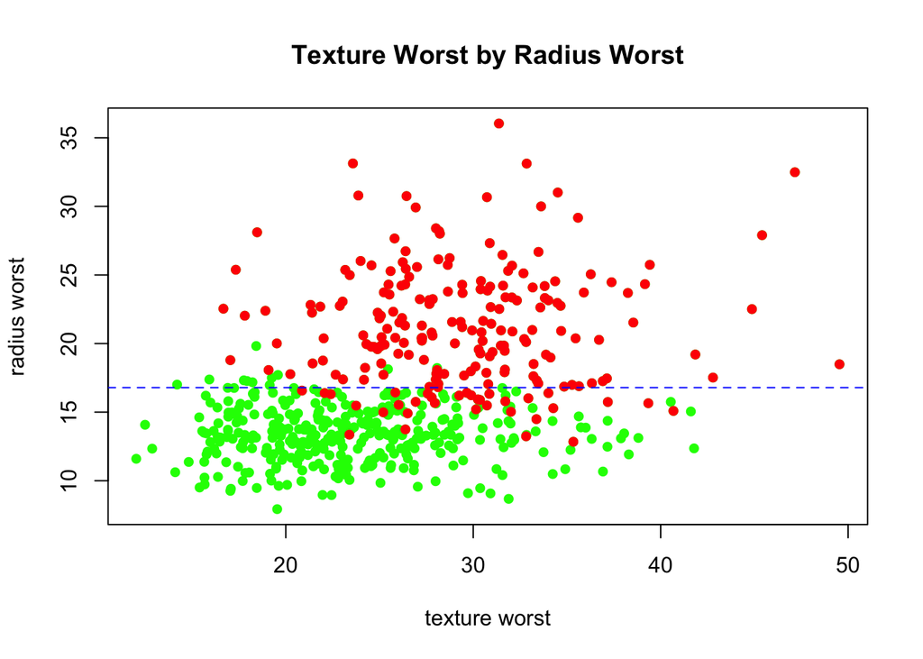

```r
> plot(dat$texture_worst, dat$radius_worst, col = "green", main = "Texture Worst by Radius Worst", xlab = "texture worst", ylab = "radius worst", pch=16)
> malignant = dat$diagnosis == "M"
> points(dat[malignant, ]$texture_worst, dat[malignant, ]$radius_worst, col = "red", pch=16)
> text_rad_fit = rpart(diagnosis ~ texture_worst + radius_worst, data=tr_dat, method="class")
> split = text_rad_fit$splits[1, "index"]
> abline(h=split, lty=2, col='blue')
```

*Similar to the previous plot, we see a clear boundary between the two features. However, in this plot we are using texture worst by concave.points worst.*

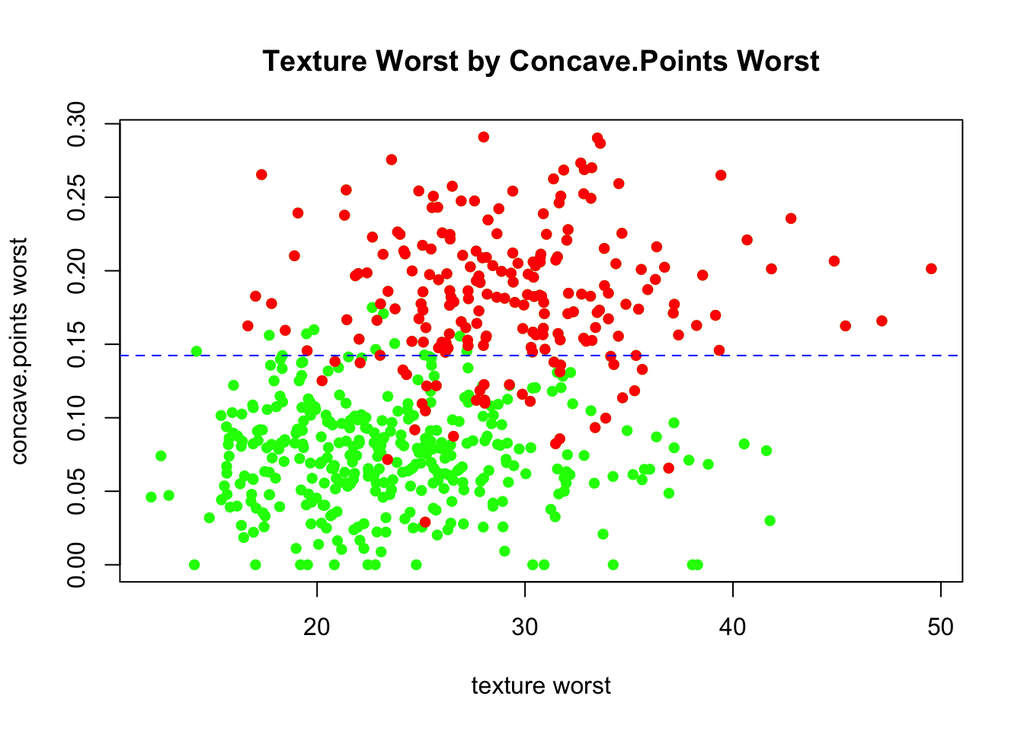

```r
> plot(dat$texture_worst, dat$concave.points_worst, col = "green", main = "Texture Worst by Concave.Points Worst", xlab = "texture worst", ylab = "concave.points worst", pch=16)
> malignant = dat$diagnosis == "M"
> points(dat[malignant, ]$texture_worst, dat[malignant, ]$concave.points_worst, col = "red", pch=16)
> text_conc_fit = rpart(diagnosis ~ texture_worst + concave.points_worst, data=tr_dat, method="class")
> split = text_conc_fit$splits[1, "index"]
> abline(h=split, lty=2, col='blue')
```

### Create Decision Tree classifier

*We are creating a decision tree classifier to predict the diagnosis feature based on the features radius worst, concave.points worst, and texture worst.*

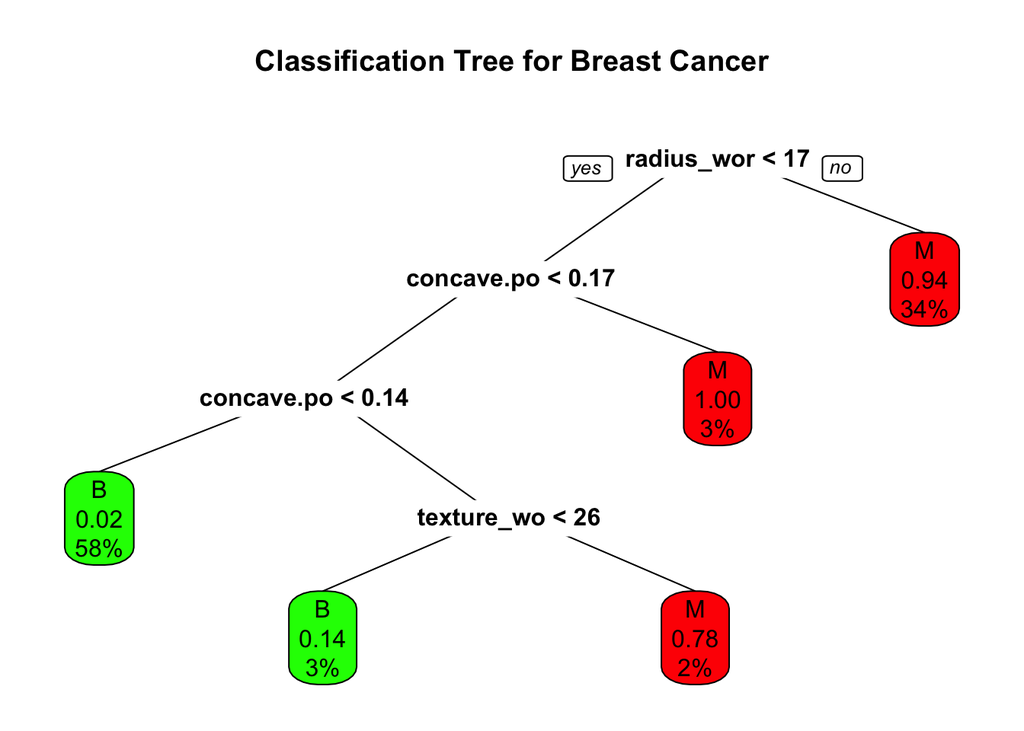

```r
> fit = rpart(diagnosis ~ radius_worst + concave.points_worst + texture_worst, data=tr_dat, method="class")
>
> prp(fit, extra=106, varlen=-10, main="Classification Tree for Breast Cancer", box.col=c("green", "red")[fit$frame$yval])
```

*From the confusion matrix for actuals vs. predicted, we can see that we have low false positives and no false negatives.*

```r
> predicts = predict(fit, te_dat, type="class")
> actuals = te_dat$diagnosis
>
> conf_mtx = table(actuals, predicts)
> conf_mtx
```

```
       predicts
actuals  B  M
      B 87  5
      M  0 51
```

*We calculate the classifier’s accuracy*

```r
> round(mean(predicts == actuals), 3)
```

```
[1] 0.965
```

*Here, we calculate the classifier’s precision*

```r
> conf_mtx[2,2] / (conf_mtx[2,2] + conf_mtx[1,2])
```

```
[1] 0.9107143
```

*Here, we calculate the classifier’s recall*

```r
> conf_mtx[2,2] / (conf_mtx[2,2] + conf_mtx[2,1])
```

```
[1] 1
```

### Learning Curve for Decision Tree Classification

*From this learning curve, we can see that this classifier has low bias and low variance because the training errors and the test error lines converge as the training set size increases.*

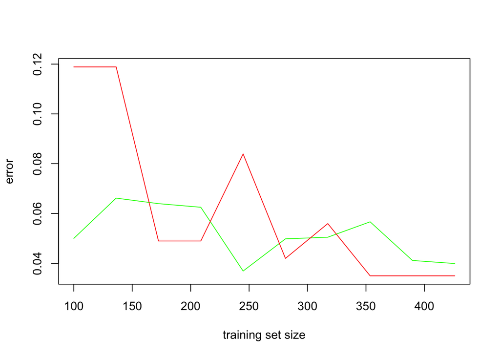